# 07_construct_figuretable_simulation

Suguru Otani

2024-01-26

# load

## Appendix. Illustrative plot and num_time_100_cobb_douglas_0.3_AR1_I0_va_dependency_0

the match elasticity with respect to unemployment is in the range 0.5–0.7.

### num_time_50_cobb_douglas_0.3_AR1_I0_va_dependency_0

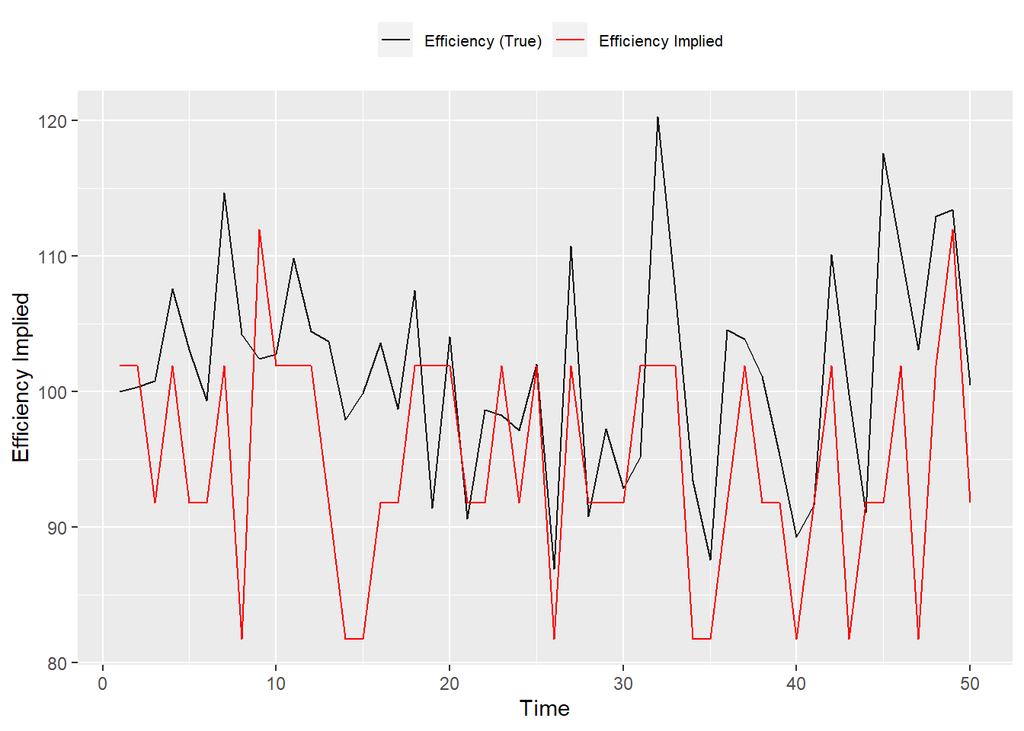

### num_time_100_cobb_douglas_0.3_AR1_I0_va_dependency_0

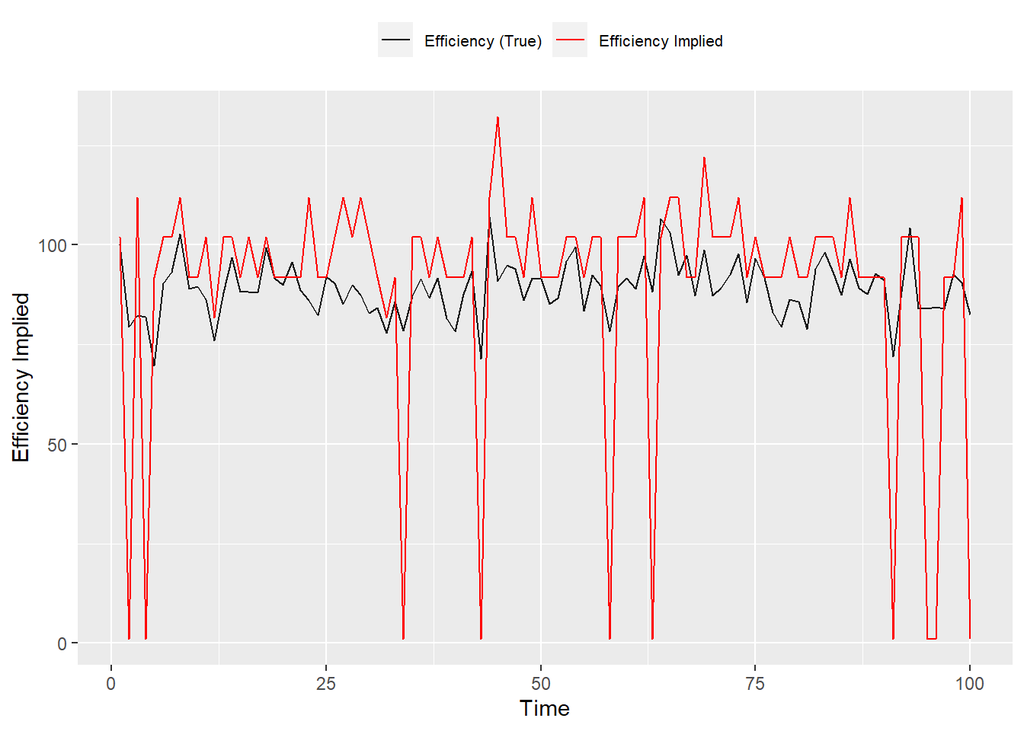

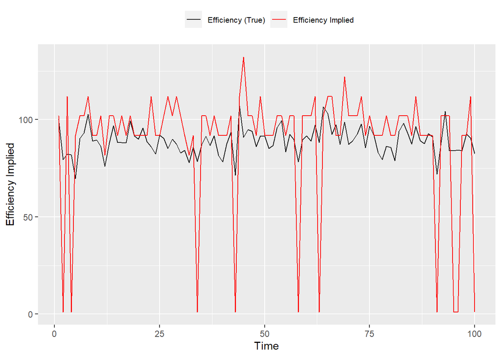

## Appendix. Illustrative plot and num_time_50_cobb_douglas_0.3_AR0_I1_va_dependency_0

the match elasticity with respect to unemployment is in the range 0.5–0.7.

### num_time_50_cobb_douglas_0.3_AR0_I1_va_dependency_0

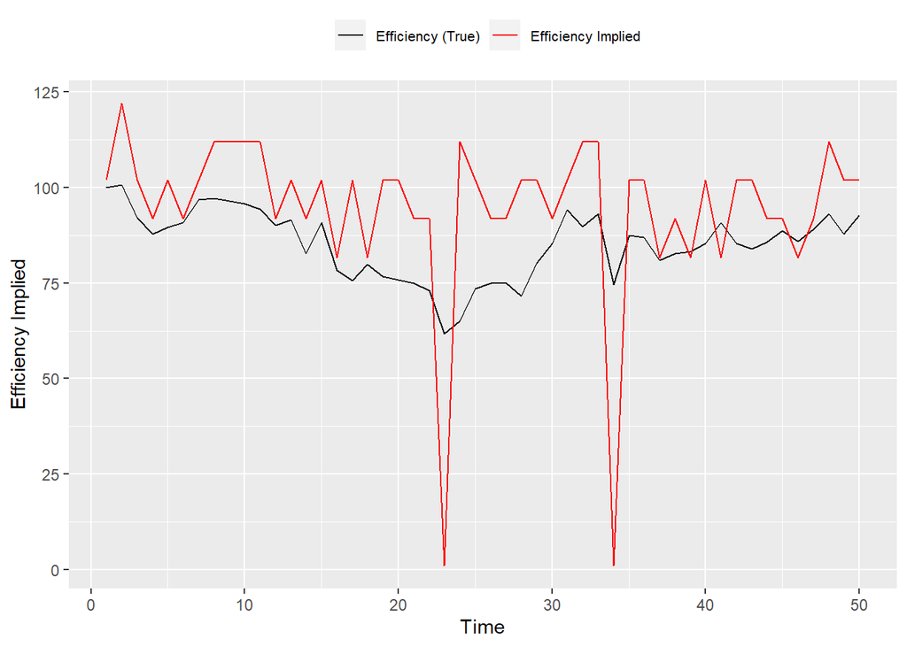

### num_time_100_cobb_douglas_0.3_AR0_I1_va_dependency_0

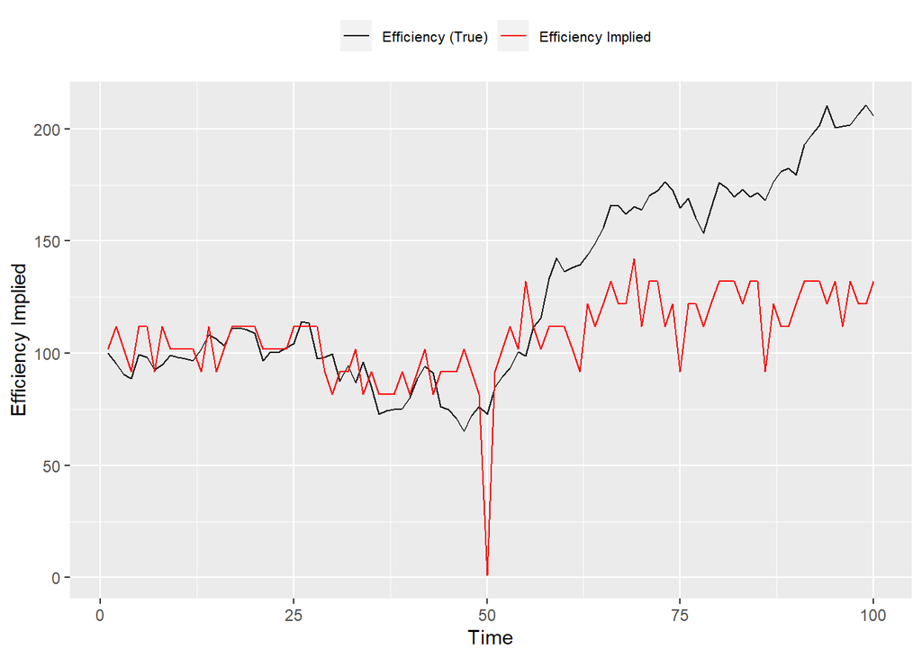

## Appendix. Illustrative plot and num_time_100_cobb_douglas_0.3_AR1_I0_va_dependency_0.1

the match elasticity with respect to unemployment is in the range 0.5–0.7.

### num_time_50_cobb_douglas_0.3_AR1_I0_va_dependency_0.1

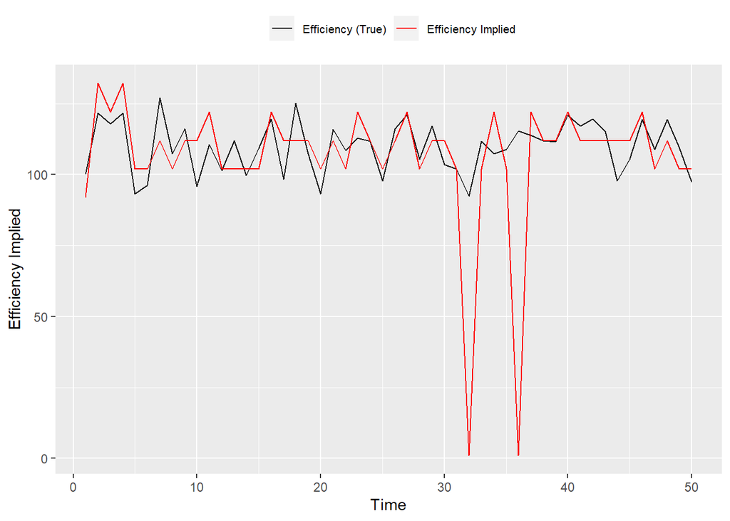

### num_time_100_cobb_douglas_0.3_AR1_I0_va_dependency_0.1

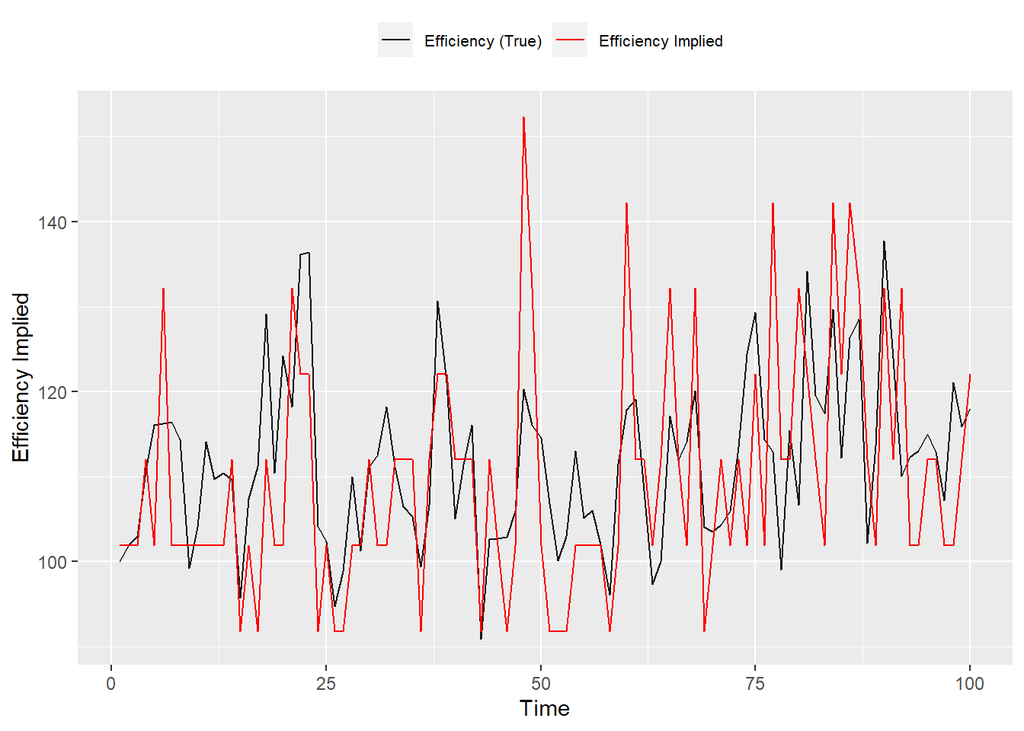

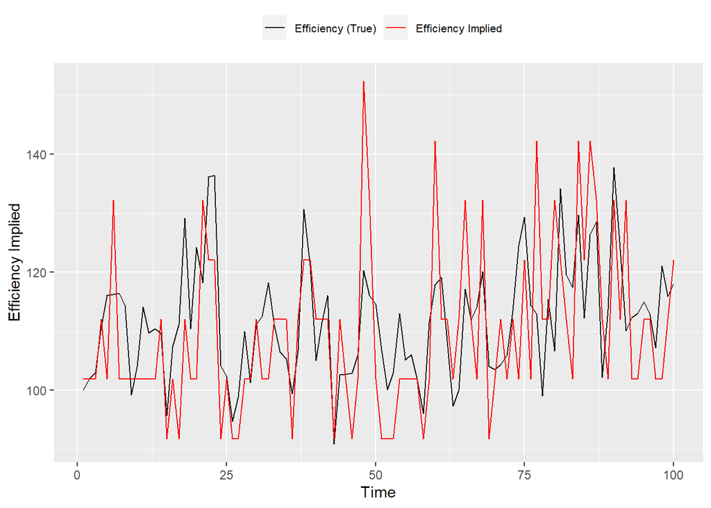

## Appendix. Illustrative plot and num_time_100_cobb_douglas_0.3_AR1_I0_va_dependency_0.2

the match elasticity with respect to unemployment is in the range 0.5–0.7.

### num_time_50_cobb_douglas_0.3_AR1_I0_va_dependency_0.2

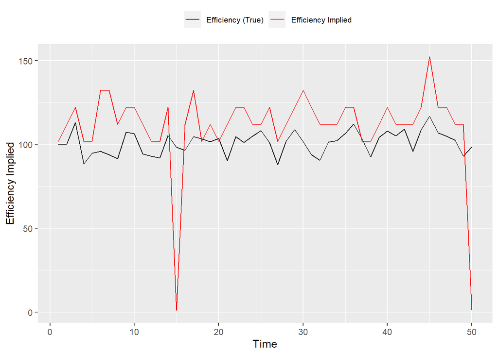

### num_time_100_cobb_douglas_0.3_AR1_I0_va_dependency_0.2

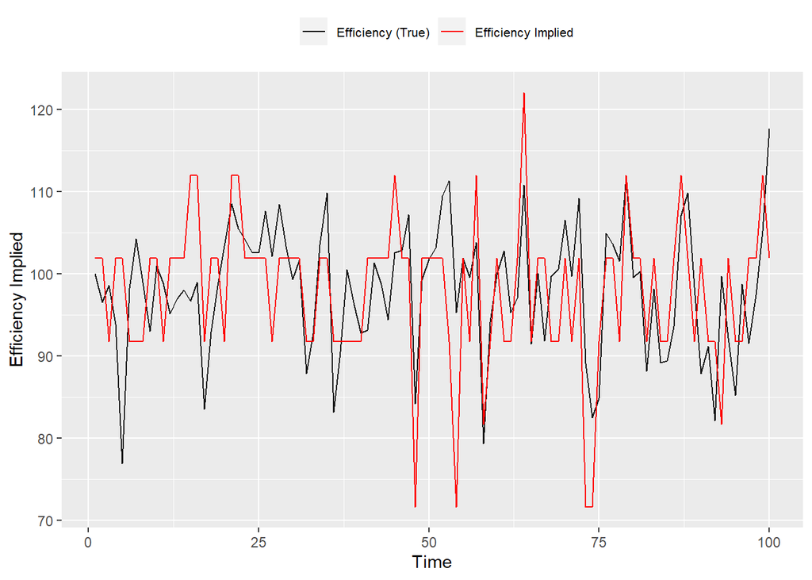

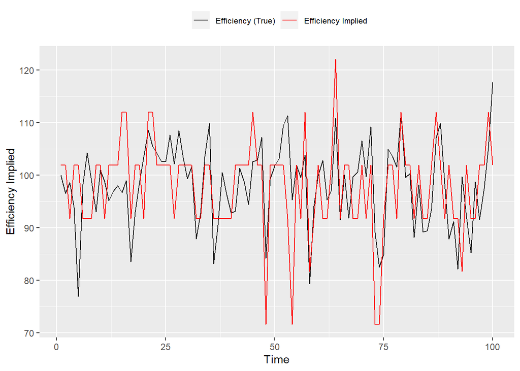